# BoE_Technical Assessmnet

Federica Mascolo

2/26/2022

[output not shown]

[output not shown]

[output not shown]

# Task I: Important firms

GWP and Total assets have been used as proxies for the firm size. Bigger firms are more important. The histograms below show respectively the first 40 firms with the highest values of GWP and Total assets for 2020. The scatterplot show the two measures jointly. On the x-axes the GWP in 2020.

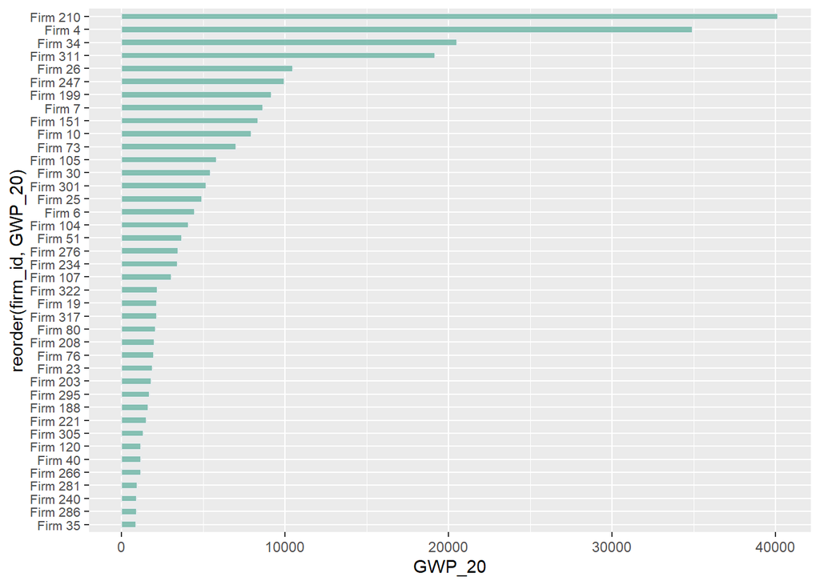

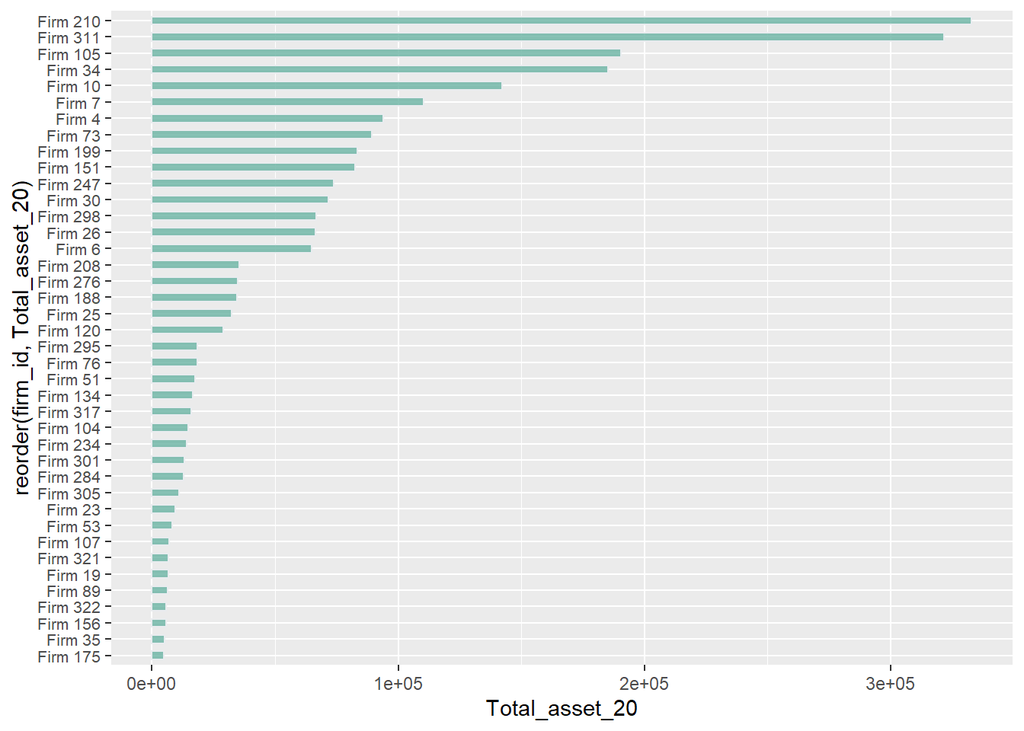

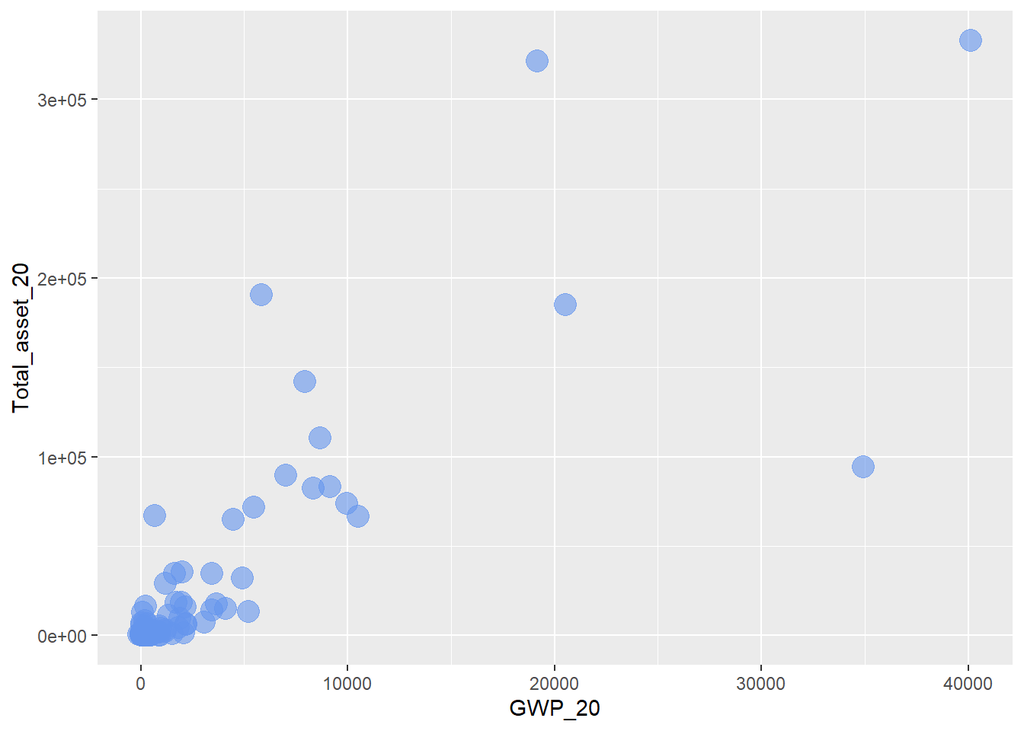

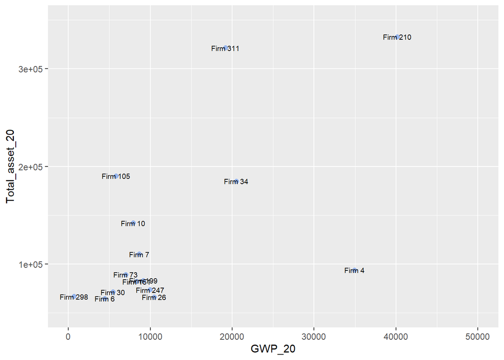

# Measure of risk:

```
##    firm_id          SCR_coverage_ratio_20
##  Length:325         Min.   :    -1.07
##  Class :character   1st Qu.:     0.00
##  Mode  :character   Median :     1.57
##                     Mean   :   514.22
##                     3rd Qu.:     2.37
##                     Max.   :166394.58
```

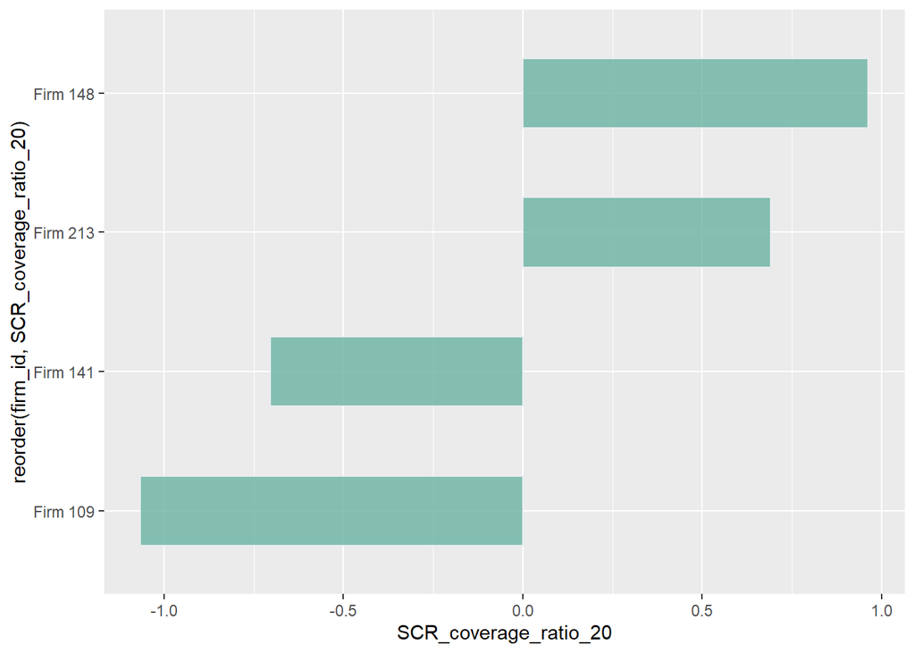

# Gross claims incurred:

The Gross claims incurred is used as a proxy for the risk of the firm. An high change between 2020 and 2019 in the Gross claims incurred can be considered as a big cost for the firm and a criterion to consider when allocating resources.

The histograms below show the first two firms with the biggest percentage change in the gross claims incurred between 2019 and 2020. While the second histogram shows from the third to the 40th firm with the bigger percentage change in the same variable. Finally, the scatterplot shows firms with higher values for total assets and Gross claims incurred.

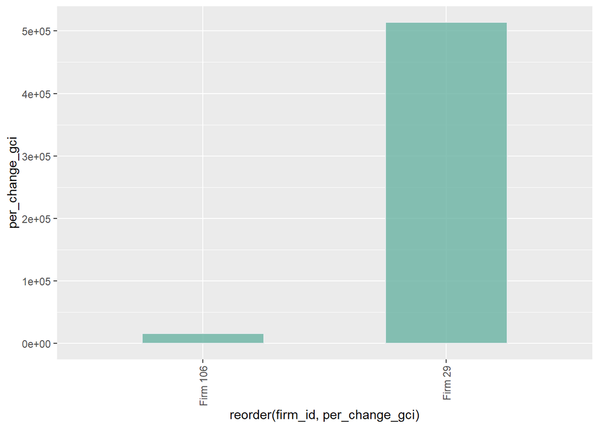

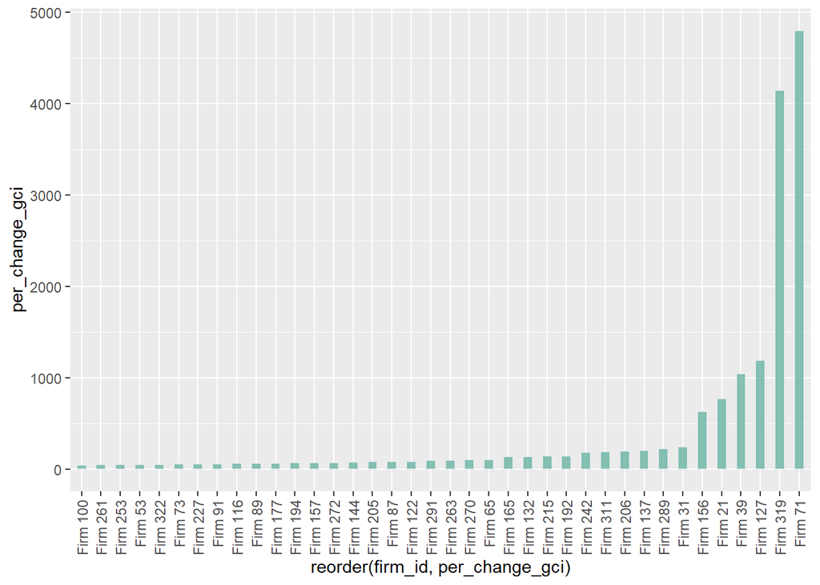

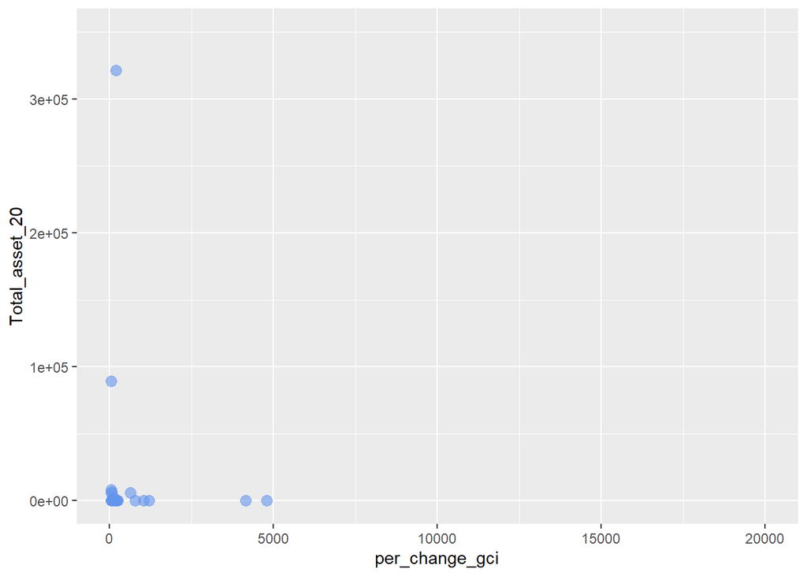

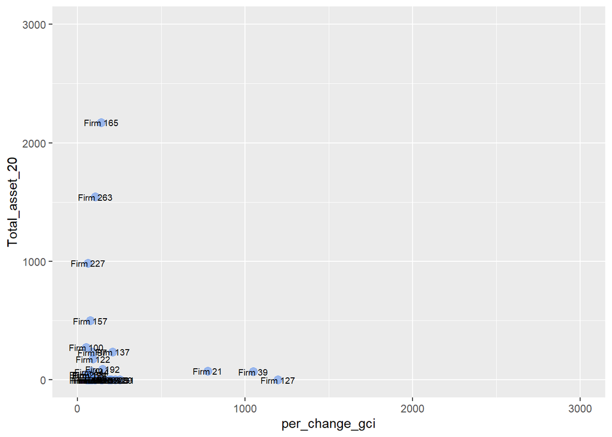

```
##    firm_id          per_change_gci    Total_asset_20
##  Length:38          Min.   :  52.45   Min.   :     0.0
##  Class :character   1st Qu.:  69.72   1st Qu.:     0.0
##  Mode  :character   Median : 105.05   Median :    46.0
##                     Mean   : 424.85   Mean   : 11678.3
##                     3rd Qu.: 200.51   3rd Qu.:   443.2
##                     Max.   :4800.87   Max.   :321563.6
```

# Selection of firms:

```
##    firm_id per_change_gci Total_asset_20 per_dev_tot_asset per_dev_gci
## 1 Firm 137       209.2764       236.4460           -5.7236    102.7508
## 2 Firm 156       633.1090      5778.5878          -12.0424    264.8934
## 3 Firm 165       141.1952      2172.6401           49.6708    203.3487
## 4 Firm 192       150.9143        91.3636         -194.2411    666.9604
## 5  Firm 21       777.3125        74.8471           39.0450    220.3909
## 6 Firm 311       197.4507    321563.5998           26.3793    976.1339
## 7  Firm 39      1049.6923        70.0423            9.4449   4498.7691
##      var_gci var_tot_asset
## 1 13951.9494  3.044881e+02
## 2    86.1555  2.006279e+06
## 3 43274.2359  1.681971e+05
## 4   815.6271  1.734489e+04
## 5    17.9180  2.589949e+03
## 6   231.3471  5.396926e+09
## 7     2.0473  1.408850e+01
```

# Task II: ML classifification of healthy/unhealthy firms

The supervised ML algorithm below is a LASSO regularization used to classify healthy and unhealthy firms. The dependent variable is the equity of the firm in 2020 modeled as a binary variable: firms with equity greater than zero are considered healthy while the rest are classified as unhealthy. The lambda parameter for LASSO has been selected with cross-validation. The assessment methods are the test error, calculated as the one minus the accuracy, and the False Positive Rate. Indeed, our focus is to reduce the number of firms wrongly classified as healthy.

```
##     Min.  1st Qu.   Median     Mean  3rd Qu.     Max.
##  -110.79     0.00    23.06   501.50   150.92 22827.37
```

```
##    Min. 1st Qu.  Median    Mean 3rd Qu.    Max.
##  0.0000  0.0000  1.0000  0.7138  1.0000  1.0000
```

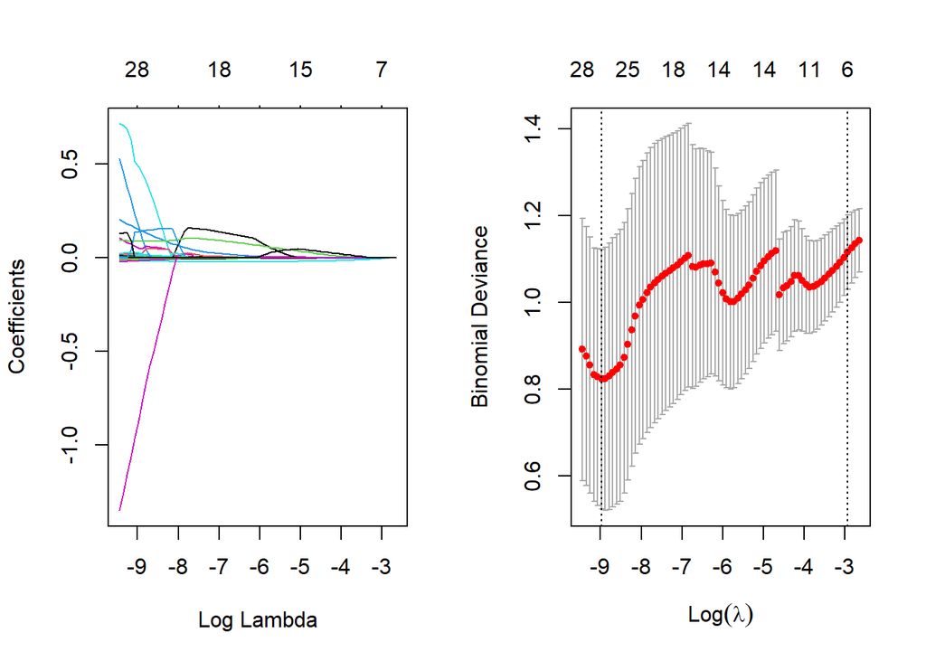

```
## 76 x 1 sparse Matrix of class "dgCMatrix"
##                                                          s1
## (Intercept)                                    9.044563e-01
## (Intercept)                                    .
## NWP_16                                         .
## NWP_17                                         .
## NWP_18                                         .
## NWP_19                                         .
## NWP_20                                         .
## SCR_16                                         .
## SCR_17                                         .
## SCR_18                                         .
## SCR_19                                         .
## SCR_20                                         .
## EoF_for_SCR_16                                 .
## EoF_for_SCR_17                                 .
## EoF_for_SCR_18                                 .
## EoF_for_SCR_19                                 .
## EoF_for_SCR_20                                 6.230785e-06
## SCR_coverage_ratio_16                         -1.360939e-03
## SCR_coverage_ratio_17                         -6.814772e-10
## SCR_coverage_ratio_18                          .
## SCR_coverage_ratio_19                          .
## SCR_coverage_ratio_20                          .
## GWP_16                                         .
## GWP_17                                         .
## GWP_18                                         .
## GWP_19                                         .
## GWP_20                                         1.637294e-05
## equity_16                                      .
## equity_17                                      .
## equity_18                                      .
## equity_19                                      1.032785e-05
## Gross_claims_incurred_16                      -6.535179e-05
## Gross_claims_incurred_17                       .
## Gross_claims_incurred_18                       .
## Gross_claims_incurred_19                       .
## Gross_claims_incurred_20                       .
## `Gross_BEL_(inc__TPs_as_whole,_pre-TMTP)__16`  .
## `Gross_BEL_(inc__TPs_as_whole,_pre-TMTP)__17`  .
```

[output cut: 23 more lines]

```
## Pure_gross_claims_ratio_16                     .
## Pure_gross_claims_ratio_17                     .
## Pure_gross_claims_ratio_18                     .
## Pure_gross_claims_ratio_19                     .
## Pure_gross_claims_ratio_20                     .
## Gross_expense_ratio_16                         .
## Gross_expense_ratio_17                         .
## Gross_expense_ratio_18                         .
## Gross_expense_ratio_19                         .
## Gross_expense_ratio_20                         .
## Gross_combined_ratio_16                        .
## Gross_combined_ratio_17                        .
## Gross_combined_ratio_18                        .
## Gross_combined_ratio_19                        .
## Gross_combined_ratio_20                        .
```

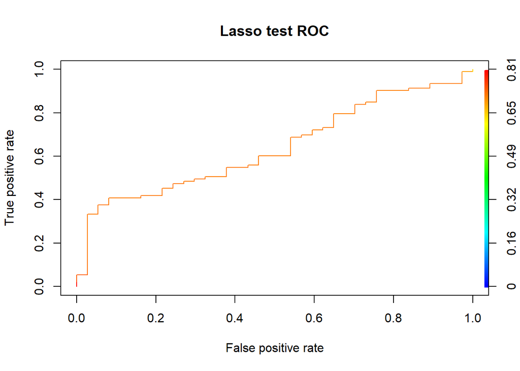

```
## [1] 0.639349
```

```
##    lasso.testerror       FPR
## 1:       0.2923077 0.2868217
```